# Evaluate effectiveness of Intelligent Sensor System - EDA report

Xing Song

2/10/2021

Among all 196 enrolled subjects, 99 are randomized to the “Linguistic” (shortened as “L”) group and 97 were randomized to the “Standard” (shortened as “S”) group.

### Table 1 - Basic Characteristic Comparison

Table 1 - Demographic and Clinical Characteristic Comparison

| var | cat | Linguistic | Standard | p.value |  |
| --- | --- | --- | --- | --- | --- |
| n |  | 99 | 97 | NA |  |
| Age_at_Enr | mean(sd) [miss] | 86.5 (8.85) [0] | 85.5 (8.26) [0] | 0.3916 |  |
| Ambulation_Time | mean(sd) [miss] | 13 (9.02) [0.58] | 14.4 (9.62) [0.57] | 0.5149 |  |
| Cadence | mean(sd) [miss] | 85.4 (21.33) [0.58] | 87.1 (22.23) [0.57] | 0.7279 |  |
| Censored | mean(sd) [miss] | 0.8 (0.43) [0] | 0.7 (0.46) [0] | 0.2973 |  |
| Cycle_Time_Differential | mean(sd) [miss] | 0 (0.05) [0.58] | 0 (0.08) [0.57] | 0.5812 |  |
| Cycle_Time_sec_L | mean(sd) [miss] | 1.5 (0.48) [0.58] | 1.5 (0.59) [0.57] | 0.9526 |  |
| Cycle_Time_sec_R | mean(sd) [miss] | 1.5 (0.5) [0.58] | 1.5 (0.58) [0.57] | 0.9780 |  |
| Distance | mean(sd) [miss] | 526.4 (204.76) [0.58] | 580.4 (227.9) [0.57] | 0.2564 |  |
| Double_Supp_Cycle_L | mean(sd) [miss] | 47.6 (13.72) [0.58] | 46.3 (17.52) [0.57] | 0.7117 |  |
| Double_Supp_Cycle_R | mean(sd) [miss] | 48.1 (12.92) [0.58] | 45.7 (16.16) [0.57] | 0.4593 |  |
| Double_Supp_Time_sec_L | mean(sd) [miss] | 0.8 (0.44) [0.58] | 0.7 (0.53) [0.57] | 0.8688 |  |
| Double_Supp_Time_sec_R | mean(sd) [miss] | 0.8 (0.42) [0.58] | 0.7 (0.52) [0.57] | 0.8049 |  |
| Double_Supp_Time_Std_Dev_Left | mean(sd) [miss] | 0.2 (0.3) [0.58] | 0.2 (0.25) [0.57] | 0.9016 |  |
| Double_Supp_Time_Std_Dev_Right | mean(sd) [miss] | 0.2 (0.31) [0.58] | 0.2 (0.24) [0.57] | 0.4818 |  |
| Double_Support_Load_GC_L | mean(sd) [miss] | 23.6 (7.22) [0.58] | 21.8 (7.54) [0.57] | 0.2851 |  |
| Double_Support_Load_GC_R | mean(sd) [miss] | 23.9 (7.1) [0.58] | 24.5 (12.6) [0.57] | 0.8183 |  |
| Double_Support_Load_Time_L | mean(sd) [miss] | 0.4 (0.21) [0.58] | 0.4 (0.25) [0.57] | 0.6140 |  |
| Double_Support_Load_Time_R | mean(sd) [miss] | 0.4 (0.23) [0.58] | 0.4 (0.33) [0.57] | 0.7817 |  |
| Double_Support_Unload_GC_L | mean(sd) [miss] | 24 (7.65) [0.58] | 24.6 (12.71) [0.57] | 0.8059 |  |
| Double_Support_Unload_GC_R | mean(sd) [miss] | 24.2 (7.04) [0.58] | 21.4 (6.3) [0.57] | 0.0649 |  |
| Double_Support_Unload_Time_L | mean(sd) [miss] | 0.4 (0.25) [0.58] | 0.4 (0.32) [0.57] | 0.8838 |  |
| Double_Support_Unload_Time_R | mean(sd) [miss] | 0.4 (0.21) [0.58] | 0.3 (0.23) [0.57] | 0.3885 |  |
| Enroll_Days | mean(sd) [miss] | 477.1 (341.23) [0] | 508.4 (408.6) [0] | 0.5612 |  |
| Foot_Length_Left | mean(sd) [miss] | 25.6 (2.56) [0.58] | 24.9 (3.75) [0.57] | 0.3429 |  |
| Foot_Length_Right | mean(sd) [miss] | 15.7 (8.75) [0.58] | 12.6 (7.34) [0.57] | 0.0843 |  |
| Foot_Width_Left | mean(sd) [miss] | 18.7 (9.15) [0.58] | 21.1 (8.02) [0.57] | 0.2074 |  |
| Foot_Width_Right | mean(sd) [miss] | 8.9 (2.04) [0.58] | 8.6 (1.66) [0.57] | 0.4064 |  |
| Functional_Amb_Profile | mean(sd) [miss] | 47.4 (30.07) [0.58] | 48.7 (30.79) [0.57] | 0.8442 |  |
| grip_left | mean(sd) [miss] | 33.7 (17) [0.26] | 32 (15.23) [0.32] | 0.5488 |  |

[output cut: 66 more lines]

No significant differences were observed between the L and S group.

### Walking Speed (10ft)

The 10-ft walking speed is measured every 6 months, 2 measurement were taken each time, and the average value is used for final analysis. 99 subjects has at least some walking speed records, while only 52 had more than 1 repeated measures, 23 from L group and 29 from S group.

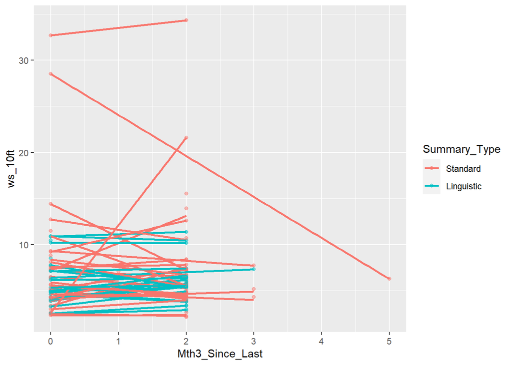

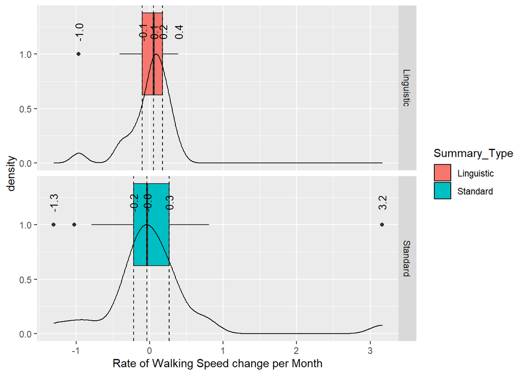

Based on the estimated personal rate of changes, we can group the patients into the following three categories: 1. “No Change”: when estimated slope is *not statistically significantly different* from 0 (p.value > 0.05) 2. “Increase”: when estimated slope is *statistically significantly greater than* 0 (p.value <= 0.05) 3. “Decrease”: when estimated slope is *statistically significantly less than* 0 (p.value <= 0.05)

Table 2 - Walking Speed Change per Month

| var | cat | Linguistic | Standard | p.value |
| --- | --- | --- | --- | --- |
| n |  | 23 | 29 | NA |
| estimate | mean(sd) [miss] | -0.002 (0.2887) [0] | 0.043 (0.7468) [0] | 0.7856 |
| change_dir | Decrease,n(%) [miss] | 6 (26.09%) [0] | 6 (20.69%) [0] | 0.3328 |
|  | Increase,n(%) [miss] | 11 (47.83%) [0] | 9 (31.03%) [0] |  |
|  | No Change,n(%) [miss] | 6 (26.09%) [0] | 14 (48.28%) [0] |  |

From the boxplots and summary table above, we observe: - There are no significant difference of Walking Speed change over time between two groups, however, the walking speed change is numerically more stable among the “Linguistic” group; - The walking speed change is a lot more variable among the the “Standard” group;due to such variability difference, we observe more extremely worse cases in the control (“Standard”) group

We further build a mixed effect model to better account for the nested variability structure, but still observed no significant difference in walking speed change between the two comparison groups.

```
## Linear mixed model fit by REML. t-tests use Satterthwaite's method [
## lmerModLmerTest]
## Formula: ws_10ft ~ Mth3_Since_Last * Summary_Type + (1 + Mth3_Since_Last |
##     Research_ID)
##    Data: walkspeed %>% filter(Repeat_Meas_n > 1)
##
## REML criterion at convergence: 689.9
##
## Scaled residuals:
##      Min       1Q   Median       3Q      Max
## -2.37733 -0.22014 -0.01747  0.13266  2.23364
##
## Random effects:
##  Groups      Name            Variance Std.Dev. Corr
##  Research_ID (Intercept)     28.074   5.299
##              Mth3_Since_Last  2.426   1.558    -0.40
##  Residual                     2.172   1.474
## Number of obs: 127, groups:  Research_ID, 52
##
## Fixed effects:
##                                        Estimate Std. Error       df t value
## (Intercept)                             8.02905    1.01990 49.86351   7.872
## Mth3_Since_Last                         0.07544    0.33990 49.36847   0.222
## Summary_TypeLinguistic                 -1.99532    1.53395 49.91118  -1.301
## Mth3_Since_Last:Summary_TypeLinguistic  0.03007    0.51830 51.08254   0.058
##                                        Pr(>|t|)
## (Intercept)                            2.67e-10 ***
## Mth3_Since_Last                           0.825
## Summary_TypeLinguistic                    0.199
## Mth3_Since_Last:Summary_TypeLinguistic    0.954
## ---
## Signif. codes:  0 '***' 0.001 '**' 0.01 '*' 0.05 '.' 0.1 ' ' 1
##
## Correlation of Fixed Effects:
##             (Intr) Mt3_S_L Smm_TL
## Mth3_Snc_Ls -0.430
## Smmry_TypLn -0.665  0.286
## M3_S_L:S_TL  0.282 -0.656  -0.426
```

```
##                                             2.5 %      97.5 %
## .sig01                                  4.2479236  6.45771744
## .sig02                                 -0.6406642 -0.09747465
## .sig03                                  1.0762663  1.99453639
## .sigma                                  1.1361988  2.01547198
## (Intercept)                             6.0326606 10.02862475
## Mth3_Since_Last                        -0.5892285  0.74503351
## Summary_TypeLinguistic                 -5.0019722  1.00759075
## Mth3_Since_Last:Summary_TypeLinguistic -0.9895617  1.04182090
```

```
## Type III Analysis of Variance Table with Satterthwaite's method
##                              Sum Sq Mean Sq NumDF  DenDF F value Pr(>F)
## Mth3_Since_Last              0.2647  0.2647     1 51.083  0.1219 0.7284
## Summary_Type                 3.6745  3.6745     1 49.911  1.6920 0.1993
## Mth3_Since_Last:Summary_Type 0.0073  0.0073     1 51.083  0.0034 0.9540
```

### Grip Strength

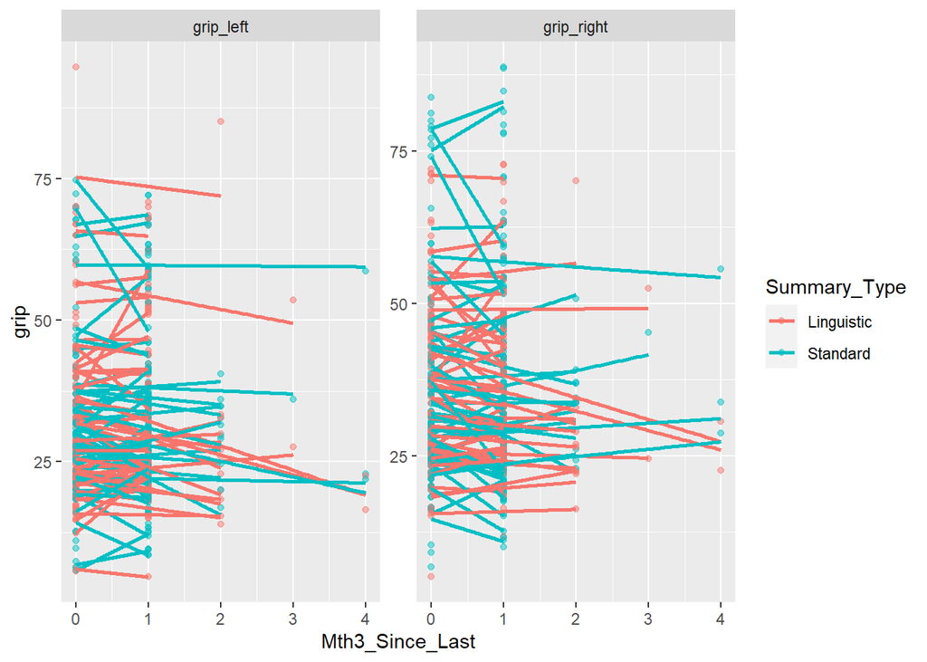

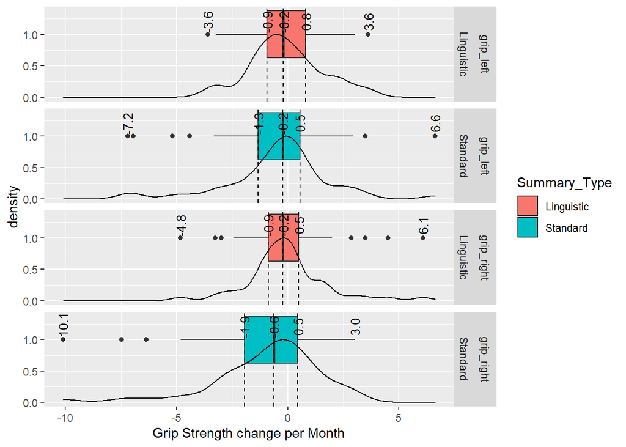

**Right Grip**

Table 3 - Right Grip Change per Month

| var | cat | Linguistic | Standard | p.value |
| --- | --- | --- | --- | --- |
| n |  | 55 | 55 | NA |
| estimate | mean(sd) [miss] | -0.062 (1.7886) [0.0182] | -0.94 (2.46) [0] | 0.0356 |
| change_dir | Decrease,n(%) [miss] | 6 (10.91%) [0] | 12 (21.82%) [0] | 0.0860 |
|  | Increase,n(%) [miss] | 9 (16.36%) [0] | 3 (5.45%) [0] |  |
|  | No Change,n(%) [miss] | 40 (72.73%) [0] | 40 (72.73%) [0] |  |

**Left Grip**

Table 4 - Left Grip Change per Month

| var | cat | Linguistic | Standard | p.value |
| --- | --- | --- | --- | --- |
| n |  | 53 | 55 | NA |
| estimate | mean(sd) [miss] | -0.082 (1.6406) [0] | -0.433 (2.3411) [0.0182] | 0.3726 |
| change_dir | Decrease,n(%) [miss] | 11 (20.75%) [0] | 8 (14.55%) [0] | 0.6042 |
|  | Increase,n(%) [miss] | 5 (9.43%) [0] | 8 (14.55%) [0] |  |
|  | No Change,n(%) [miss] | 37 (69.81%) [0] | 39 (70.91%) [0] |  |

The “No change”, “Increase”, and “Decrease” groups are defined the similar way as above. By comparing the personalized rate of change for grip strength, we observed that **there right grip strength reduced with a rate that is significantly slower than the standard group**.

### GaitRite Measurement

GaitRite metrics were collected every 6 months with 82 different metrics reported. 84 subjects has at least some walking speed records, while only 65 had more than 2 repeated measures over time, 30 from L group and 35 from S group.

Table 2 - GLMM-Model-based screening results of GaitRite metrics

| GaitRite_meas | coef | Estimate | Std..Error | df | t.value | Pr…t.. | sig |
| --- | --- | --- | --- | --- | --- | --- | --- |
| Step_Len_Std_Dev_Left | Mth3_Since_Last | 0.993 | 0.4137 | 22.6241 | 2.4001 | 0.025 | 1 |
|  | Summary_TypeLinguistic | 1.1066 | 0.691 | 168.3688 | 1.6015 | 0.1111 | 1 |
|  | Mth3_Since_Last:Summary_TypeLinguistic | -1.4102 | 0.7715 | 27.5546 | -1.8278 | 0.0784 | 1 |
| Distance | Mth3_Since_Last | -23.842 | 12.715 | 84.8868 | -1.8751 | 0.0642 | 1 |
|  | Summary_TypeLinguistic | -73.8893 | 35.8997 | 58.246 | -2.0582 | 0.0441 | 1 |
|  | Mth3_Since_Last:Summary_TypeLinguistic | 26.8693 | 23.252 | 57.6015 | 1.1556 | 0.2526 | 1 |
| Step_Extremity_ratio_L | Mth3_Since_Last | -0.0205 | 0.0149 | 23.019 | -1.3756 | 0.1822 | 1 |
|  | Summary_TypeLinguistic | -0.0873 | 0.0472 | 63.4879 | -1.8481 | 0.0692 | 1 |
|  | Mth3_Since_Last:Summary_TypeLinguistic | 0.0149 | 0.0278 | 20.0701 | 0.5374 | 0.5969 | 1 |

I performed mixed-model-based screening over all the 82 gaitrite variables, and presented the results in Table 2. 3 has showed some significance (p-value <= 0.1) in either overall difference of metrics or change of the metrics over time.

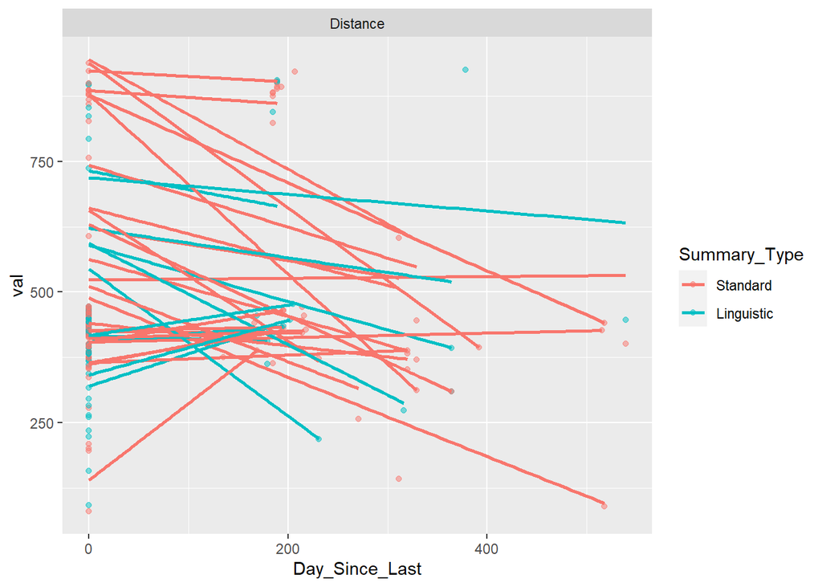

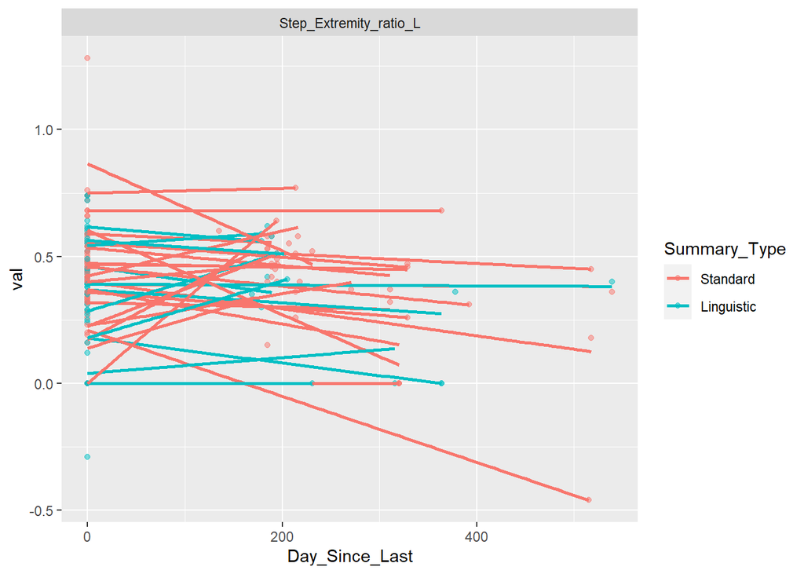

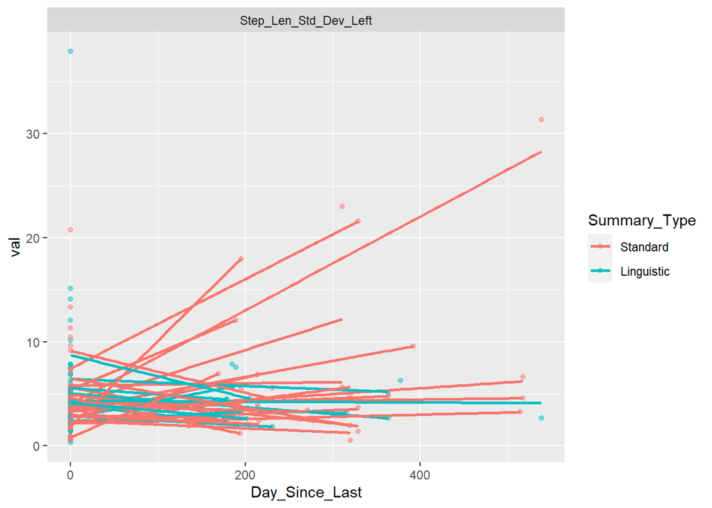